# IDA_HW8

987144, 987154 And 986384

January 15, 2020

# Exercise 1: Adressing hypotheses about coin flips with hypothesis testing (45 points)

```r
plot_binomial <- function(theta, N, highlight = NULL) {
  # put the data together
  plotData <- tibble(x = 0:N, y = dbinom(0:N, N, theta))
  # make a simple bar plot
  out_plot <- ggplot(plotData, aes(x = x , y = y )) +
    geom_col(fill = "gray", width = 0.35) +
    labs(
      x = "test statistic k",
      y =  str_c("Binomial(k, ", N, ", ", theta, ")")
    )
  # if given, highlight some bars in red
  if (!is.null(highlight)) {
    plotData2 = tibble(x = highlight, y = dbinom(highlight, N, theta))
    out_plot <- out_plot +
      geom_col(
        data = plotData2,
        aes(x = x, y = y),
        fill = "firebrick",
        width = 0.35
      )  +
      ggtitle(
        str_c(
          "Prob. selected values: ",
          sum(dbinom(highlight, N, theta)) %>% signif(5)
          )
        )
  }
  out_plot
}
```

# Case 1: Manufacturer says: “$\theta$=0.8” (20 points)

## Fix the null-hypothesis (2 points)

Null Hypothesis: theta = 0.8

Alternative Hypothesis: theta != 0.8

## Plot the sampling distribution (2 points)

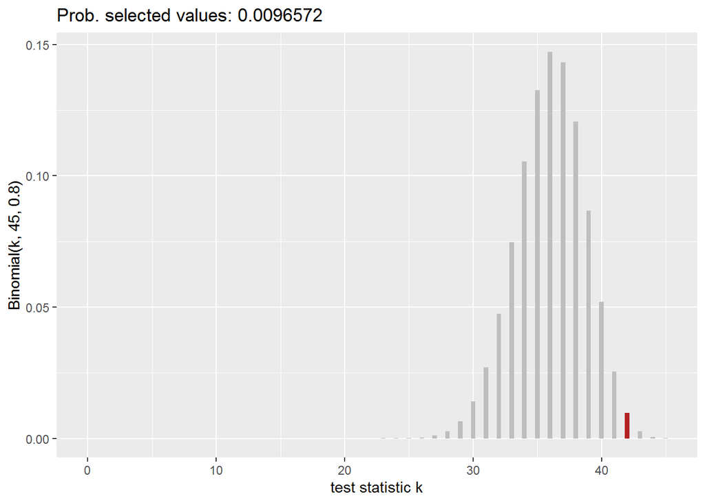

```r
plot_binomial(theta = 0.8, N = 45, highlight = c(42))
```

## More extreme values of k

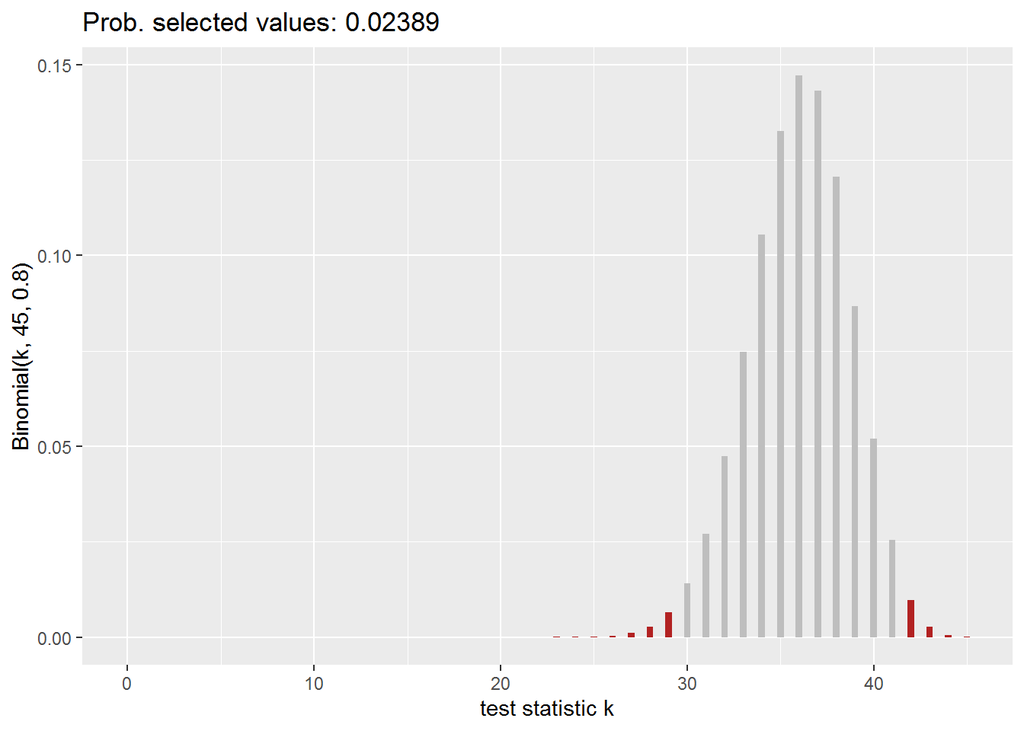

```r
plot_binomial(theta = 0.8, N = 45, highlight = which(dbinom(0:45, 45,p=0.8) <= dbinom(42, 45,p=0.8))-1)
```

## One- or two-sided test?

This is a two sided test as the alternative hypotheses is not directed. Alternative hypothesis depends on both (left and right) extreme values.

## p-value (2 points)

p-value = 0.02389

## Compare to built-in function

```r
binom.test(
  x = 42,     # observed successes
  n = 45,    # total nr. observations
  p = 0.8   # null hypothesis

)
```

```
##
##  Exact binomial test
##
## data:  42 and 45
## number of successes = 42, number of trials = 45, p-value = 0.02389
## alternative hypothesis: true probability of success is not equal to 0.8
## 95 percent confidence interval:
##  0.8173155 0.9860349
## sample estimates:
## probability of success
##              0.9333333
```

# Case 2: Manufacturer says: “$\theta$<=0.3” (20 points)

## Fix the null-hypothesis (2 points)

Null hypotesis: $\theta$<=0.3

Alternative hypothesis: $\theta$>0.3

## Plot the sampling distribution (2 points)

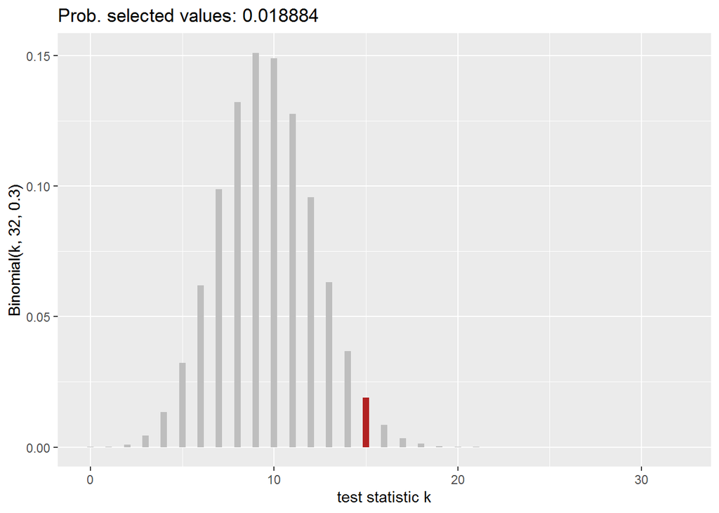

```r
plot_binomial(theta = 0.3, N = 32, highlight = c(15))
```

## More extreme values of k (4 points)

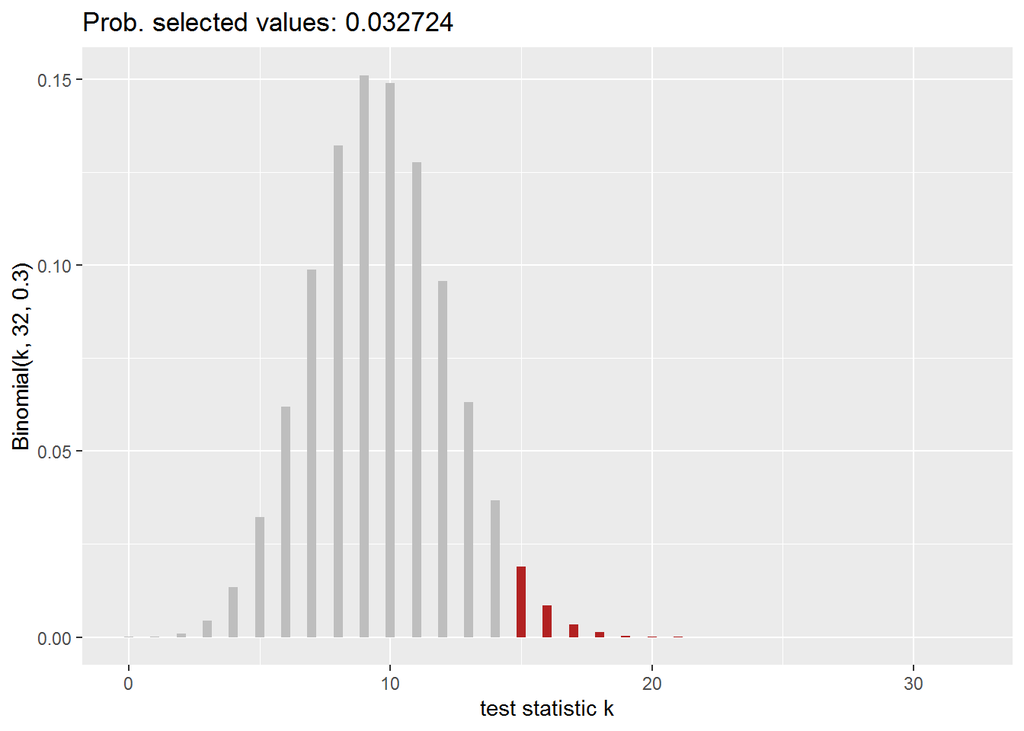

```r
plot_binomial(theta = 0.3, N = 32, highlight = c(15:32))
```

## p-value (2 points)

p-value = 0.03272

## Compare to built-in function (2 points)

```r
binom.test(
  x = 15,     # observed successes
  n = 32,     # total nr. observations
  p = 0.3,    # null hypothesis
  alternative = 'greater'
)
```

```
##
##  Exact binomial test
##
## data:  15 and 32
## number of successes = 15, number of trials = 32, p-value = 0.03272
## alternative hypothesis: true probability of success is greater than 0.3
## 95 percent confidence interval:
##  0.3154413 1.0000000
## sample estimates:
## probability of success
##                0.46875
```

## Interpret and report your results (6 points)

We conducted a binomial test assuming that the coin is fair $\theta <= 0.3$ and observed a significant test result (N= 32, p = 0.03272). As the p value is lower the $\alpha$ so we can reject the null hypothesis.

# Case 3: Manufacturer says: “$\theta$=>0.6” (20 points)

## Fix the null-hypothesis (2 points)

Null hypotesis: $\theta$=>0.6

Alternative hypothesis: $\theta$<0.6

## Plot the sampling distribution (2 points)

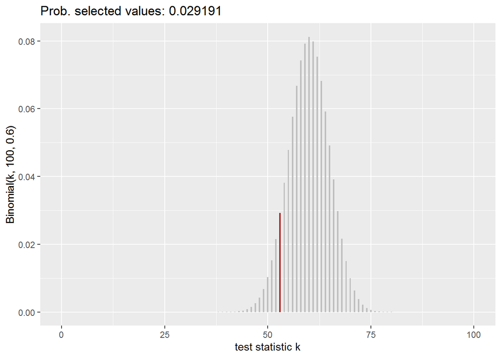

```r
plot_binomial(theta = 0.6, N = 100, highlight = c(53))
```

##More extreme values of k (4 points)

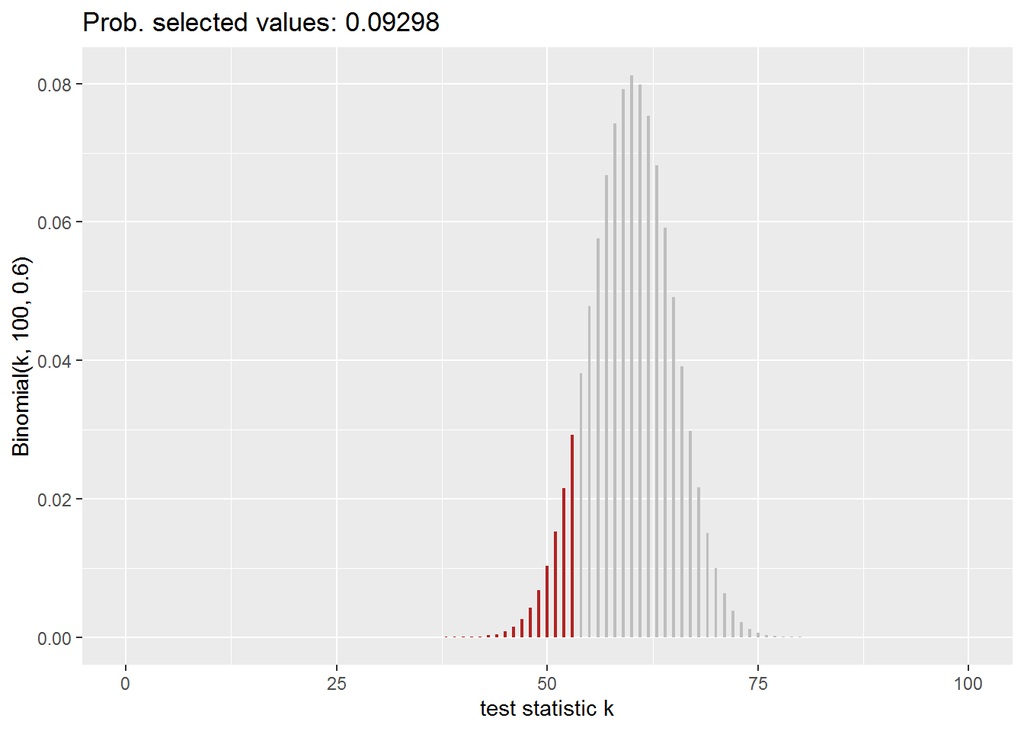

```r
plot_binomial(theta = 0.6, N = 100, highlight = c(1:53))
```

##One- or two-sided test? (2 points)

Its a one sided test as we are interested in the $\theta$=>0.6 which means that alternative hypotesis is a directed hypothesis..

## p-value (2 points)

p-value = 0.09298

## Compare to built-in function (2 points)

```r
binom.test(
  x = 53,     # observed successes
  n = 100,     # total nr. observations
  p = 0.6,    # null hypothesis
  alternative = 'less'
)
```

```
##
##  Exact binomial test
##
## data:  53 and 100
## number of successes = 53, number of trials = 100, p-value =
## 0.09298
## alternative hypothesis: true probability of success is less than 0.6
## 95 percent confidence interval:
##  0.0000000 0.6155513
## sample estimates:
## probability of success
##                   0.53
```

## Interpret and report your results (6 points)

We conducted a binomial test assuming that the coin is fair $\theta => 0.6$ and observed (N= 100, p = 0.09298). The p-value is greater than the $\alpha$ so we will not be able to reject the null hypothesis.

# Exercise 2: Pearson’s $\chi^2$test of goodness of fit

## Plot data and prediction

```r
n_obs <- tibble(
  mega_winner = 1,
  winner = 2,
  free_ride = 10,
  consolation = 18,
  blank = 19
)

expected <- tibble(
  mega_winner = 5,
  winner = 15,
  free_ride = 15,
  consolation = 35,
  blank = 30
) * sum(n_obs) / 100


expected <- expected %>%
pivot_longer(cols = -10 ,names_to = "type", values_to = "scores")
n_obs <- n_obs %>%
pivot_longer(cols = -10 ,names_to = "type", values_to = "scores")
expected <- add_column(expected, condition = "expected")
n_obs <- add_column(n_obs, condition = "n_obs")
final <- full_join(n_obs, expected)
```

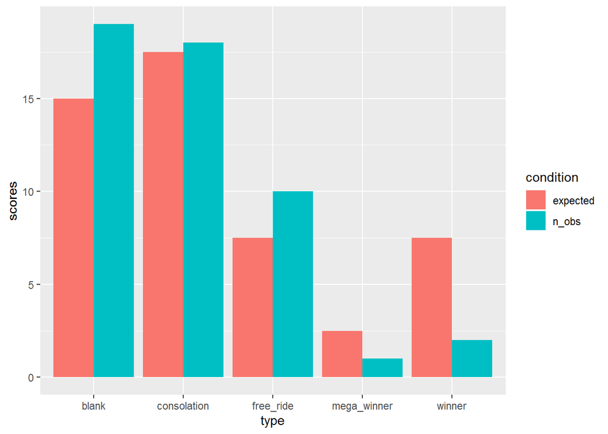

```r
ggplot(final, aes(fill =condition, x = type, y= scores)) + geom_bar(position="dodge", stat="identity")
```

```r
final
```

```
## # A tibble: 10 x 3
##    type        scores condition
##    <chr>        <dbl> <chr>
##  1 mega_winner    1   n_obs
##  2 winner         2   n_obs
##  3 free_ride     10   n_obs
##  4 consolation   18   n_obs
##  5 blank         19   n_obs
##  6 mega_winner    2.5 expected
##  7 winner         7.5 expected
##  8 free_ride      7.5 expected
##  9 consolation   17.5 expected
## 10 blank         15   expected
```

## Test the vendor’s claim

```r
chisq.test(n_obs$scores, expected$scores)
```

```
##
##  Pearson's Chi-squared test
##
## data:  n_obs$scores and expected$scores
## X-squared = 15, df = 12, p-value = 0.2414
```

Observed values do not deviate significantly from the expected values claimed by the vendor.The p-value is greater than the significant value $\alpha$ = 0.05 ($\chi ^2 test,\ with\ \chi^2 = 15, \ df = 12, \ p-value = 0.2414$ )

# Exercise 3: Some claims about frequentist testing (15 points)

1. A p-value of 0.00615 should be interpreted as implying that the probability that the null-hypothesis is true is below 1%. Its True. But we never do say that the null hypothesis is true or accepted. So the sentence is “that the probability that the null-hypothesis is not rejected is below 1%”
2. If we obtain a 95% confidence interval of [0.2;0.4] for a binomial test, then we know that a two-sided binomial test for the null hypothesis $\theta$=0.1 will be statistically significant at the significance level $\alpha$=0.05. Its True.
3. If we obtain a significant test result for a two-sided binomial test for the null hypothesis $\theta$=0.1, we know that the corresponding 95% CI for the observed data will include the value 0.1. Its False. As we reject the null hypothesis, the value 0.1 will be not exist within the confidence interval.
4. The Central Limit Theorem implies that a binomial distribution for large enough N is closely approximated by a normal distribution, no matter what $\theta$ we are assuming. Its true
5. If we obtain a significant test result at significance level $\alpha$=0.05, then this means that when we repeat the exact same experiment we will find a significant result in at least 95% of the cases.  
   Its True.